# RCN_RAD

Katherine Silliman

7/21/2021

If you want to run the acompanying code chunks, install Docker container.

```r
library(ggplot2)
library(SeqArray)
library(tidyverse)
```

Dani to do: make a dockerfile with all the packages used in this Rscript for reproducibility

Example files needed: example strata file ‘data/example.metadata.csv’, example vcf for PCA ‘./data/test.vcf’

# Reduced Representation Sequencing (RADseq/GBS)

What kinds of protocols is this advice relevant to?  
“Restriction-site Associated DNA sequencing” - RADseq - combines restriction enzymes with next-gen, massively parallel, short-read sequencing. RADseq involves the use of restriction enzymes which are used to shear DNA at selected sites. RADseq comes in different flavors. Double-digest RADseq (ddRAD; Peterson et al.,2012) selects markers with two restriction enzymes with different cut frequencies. Genotype-by-Sequencing (GBS; Elshire et al., 2011) uses a frequent-cutting restriction enzyme with PCR size selection. See this review for a comparision of some of the more popular protocols (link). In this guide we use the term “RADseq” to refer to any of these protocols, including those that don’t involve random shearing of data. When recommendations are specific to a certain type of RAD/GBS, we will explicitly say so.

characteristics of radseq that are different/ important to know compared to other types of sequencing

Using RADseq to generate single nucleotide polymorphisms (SNPs) involves 1) library preparation in the lab, 2) bioinformatic processing through assembly and/or mapping to a reference, then 3) filtering of SNPs and individuals for quality. All of these steps can (and will) introduce some error, so the goal is to minimize this error through mitigation steps at all three parts of the process. Every dataset is different [add more about philosophy over best practices].  
Much of this guide is directly inspired by this excellent review paper by O’Leary et al. (2018), especially the section on minimizing errors due to library prep. We recommend reading and cross-referencing with this paper, and citing it if you follow its suggestions. Table 1 from this paper summarizes the various potential issues that can arise from RAD datasets and some mitigation steps. The goal of this guide is to expand on the O’Leary paper and provide some example code to help implement quality control and mitigation steps.

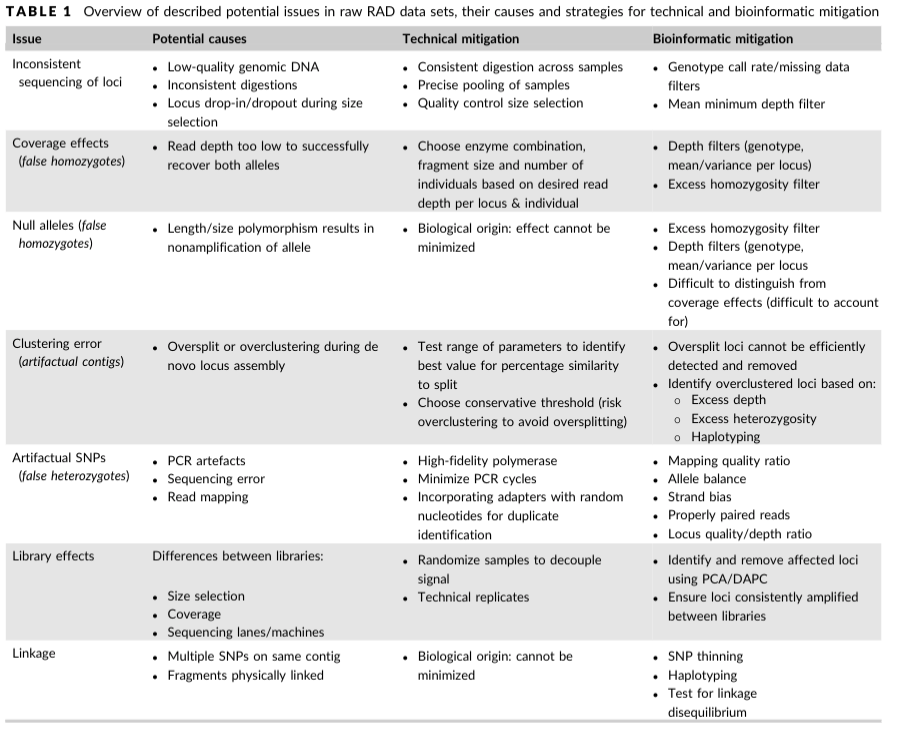

Table 1 from O’Leary et al. 2018.

## Considerations During Lab Work – Setting up for Success

There are steps you can take before you even sequence RAD libraries that can help minimize issues downstream. Here, we use “library” to refer to a set of RADseq fragments from a group of individuals that are barcoded and sequenced together on a single lane or group of lanes. While specific RAD library prep methods have their own nuances for minimizing error, there are some steps you can take that are common across methods.

- If this RAD/GBS method has not been done in your species or in your molecular lab setup before, spend some time optimizing the protocol using a representative subset of individuals. Then try to keep everything about the library prep as consistent as possible across samples (eg, DNA extraction kit, PCR cycles, sequencing platform). This isn’t always possible, especially if you need to optimize the protocol for certain tricky samples. Just make sure to keep track of everything!
- Randomize samples across library prep batches and sequencing lanes! For example, if you are sequencing two different groups of samples on two different sequencing lanes, make sure they are randomized in respect to sample location or whatever your groups of interest are. If you are preparing groups of individuals in different batches to be pooled later, randomize across these batches. Alicia MY even recommends randomizing across DNA extractions, especially if the person doing the extractions is new to molecular work. This is to allow you to control for potential batch effects that are often observed with RAD data.

```r
# This code reads in a comma-delimited STRATA/meta-data file, randomises samples, and returns a file with wells and plates and duplicates which may be used to assist with plating libraries
# ** TODO** will need to consider where to duplicate samples - need to consider STARTA, DOC, ect..?
# maybe have user write in a list of samples to replicate

wells = 96 # how many wells can you use on your plate?
data.in = read.table("./data/example.metadata.csv", sep = ",", header = T) # each sample should be in its own ROW
l = length(data.in[,1])
plates = rep(1:length(ceiling(101/ wells)), wells)
data.out = cbind(
   data.in[sample(1:l, l, replace = F),], # randomise samples
   PLATEID = plates[c(1:l)],  # add plate info
   WELLID = rep(1:wells, length(unique(plates)))[1:l] # add well info
) # add duplicates **TODO**

# print example
 print(head(data.out))
```

```
##    TARGET_ID INDIVIDUALS STRATA       LAT     LONG PLATEID WELLID
## 84     CM073       CM073   ECSI -43.89483 172.3957       1      1
## 43     CM236       CM236    VIC        NA       NA       1      2
## 88     CM235       CM235    VIC        NA       NA       1      3
## 68     CM065       CM065   ECSI -44.76150 171.2648       1      4
## 65     CM210       CM210     SA        NA       NA       1      5
## 48     CM209       CM209     SA        NA       NA       1      6
```

```r
#save to file
```

- Keep track of all potential batch effect sources in a Metadata file (eg, storage conditions of tissue/DNA, date/method of DNA extraction, date/method library prep batch, sequencing lane).
- Have a core set of 2-4 technical sample replicates across all libraries. Ideally these are true technical replicates from library preparation to sequencing, but even just sequencing replicates can be useful for downstream quality control.

## Principles for Analyzing Your Data

### Steps for a robust RAD analysis

This is just one approach for working through your data. Some people will prefer to run just a subset of samples through a pipeline at first and evaluate parameters, then run all the samples through. Either way, be prepared to make MULTIPLE assemblies and go through this process iteratively, especially if this is a new-to-you study system.

1. Look at your raw data.
2. Run an assembly pipeline through to a SNP dataset, using either all samples or a representative subset. Parameters can come from those used in a similar study, or default parameters.
3. Filter your data minimally, then evaluate for potential sources of error.
4. Subset or remove individuals based on initial evaluation.
5. Using a representative subset of samples, test key parameters to optimize your assembly.
6. Run your optimized assembly on all non-removed samples.
7. Evaluate the difference between multiple filtering schemes for your analyses of interest. *Popgen analysis guide coming soon*
8. Repeat as needed.

### First, look at the raw data!

Always look at your data with fastqc(link) before starting an assembly. First, this is a good check to just make sure the sequencing worked. If you have demultiplexed data, you can use multiqc(link) to generate fastqc plots for all individuals and quickly identify ones that did not sequence well.  
Check out [this informative tutorial](https://datacarpentry.org/wrangling-genomics/02-quality-control/index.html) on running fastqc and interpreting the output.  
Do you have a lot of adapter sequences? Are the ends of your reads very low quality? If so, you should expect a fair amount of trimming and read filtering to occur prior to assembly. If that doesn’t occur or if too many reads are being filtered so as to only recover a small number of SNPs, something might need to be tweaked with your trimming and filtering step. See how to evaluate for sequencing error

You should also look at the top few reads in the Terminal.

[output not shown]

If the sequencing center gave you one fastq file with all your samples, you should expect to see a barcode sequence, followed by the cutsite at the start of the read. If the Data are already demultiplexed (as the example is), you should only see the cutsite overhang (in this case, CWGC). Sometimes you can look at your fastq data files and see that there was a problem with the sequencing such that the cut site is either offset by one or more bases, or contains many errors. If this is not being addressed by the default filtering steps in your assembly pipeline, you can trim off N bases from the beginning or end of R1 and R2 reads in ipyrad (`trim_reads` param), or with cutadapt before using stacks, or customize the Trimmoatic step for dDocent.

### Evaluate potential confounding factors

#### The power of PCA

One of the most powerful methods for exploring your data for issues is a Principle Components Analysis (see [here](https://michaelaalcorn.medium.com/yet-another-pca-explanation-727dff6ce26a) for a linear algebr-based explanation of PCA). From [this genetics tutorial](https://comppopgenworkshop2019.readthedocs.io/en/latest/contents/03_pca/pca.html): “To understand how PCA works, consider a single individual and its representation by its 593,124 markers. Formally, each individual is a point in a 593,124-dimensional space, where each dimension can take only the three possible genotypes indicated above, or have missing data. To visualise this high-dimensional dataset, we would like to project it down to two dimensions. But as there are many ways to project the shadow of a three-dimensional object on a two dimensional plane, there are many (and even more) ways to project a 593,124-dimensional cloud of points to two dimensions. What PCA does is figuring out the “best” way to do this project in order to visualise the major components of variance in the data.

As soon as you have a file with SNPs for all samples, before extensive filtering or playing with parameters, do a PCA on it and look at all the axes with the most variation. Be careful that you understand how missing data is imputed for PCA.

(?) dani asks: you want me to make this take multiple different vcfs from pipeline outputs for plotting? should we implement pcANGSD which can handle missing data better (?)  
K: Making it take multiple vcfs is a secondary goal, and can be added later if we have time/interest. Adding a code example for pcANGSD would be useful though.

(?) K: I just realized we need to filter for linkage before doing PCA. adding that code now below. (?)

Doing a PCA with SeqArray and SNPRelate in R. Filtering for SNPs with a MSF > 2.5%

```r
## read in VCF and convert to GDS format
#vcf.file = "./data/test.vcf"
#seqVCF2GDS(vcf.file, "test.gds.rad", storage.option="ZIP_RA")

# read in existing gds file
filename = "data/test.gds.rad"
gdsin= SeqArray::seqOpen(filename,)
# summarize the data
print(paste0("The number of SAMPLES in data: ", length(c(SeqArray::seqGetData(gdsin, "sample.id")))))
```

```
## [1] "The number of SAMPLES in data: 93"
```

```r
print(paste0("The number of SNPs in data: ",  length(c(SeqArray::seqGetData(gdsin, "variant.id")))))
```

```
## [1] "The number of SNPs in data: 35559"
```

```r
#read in metadata
sample.ids = seqGetData(gdsin, "sample.id")
sample.strata =  read.table("data/test.metadata.csv", header = T, sep = "\t") %>%
                  dplyr::select(TARGET_ID, STRATA, LONG, LAT, PLATE)
id.order = sapply(sample.ids, function(x,df){which(df$TARGET_ID == x)}, df=sample.strata) #incase your strata file is not in the same order as your vcf
sample.strata.order = sample.strata[id.order,]

# get pruned SNPs
# NOT WORKING YET, issue with chromosome names
# Try this with vcf https://github.com/zhengxwen/SNPRelate/issues/10
#snpset <- SNPRelate::snpgdsLDpruning(gdsin, ld.threshold=0.2, autosome.only = F, start.pos="random", num.thread=1)
#snpset.id <- unlist(unname(snpset))

# PCA only on SNPs with a minor allele freq greater than 2.5%
pca.out = SNPRelate::snpgdsPCA(autosome.only = F, gdsin, num.thread=2, remove.monosnp = T, maf = 0.025)
```

```
## Principal Component Analysis (PCA) on genotypes:
## Calculating allele counts/frequencies ...
## Excluding 14,519 SNVs (monomorphic: TRUE, MAF: 0.025, missing rate: NaN)
## Working space: 93 samples, 21,040 SNVs
##     using 2 (CPU) cores
## CPU capabilities: Double-Precision SSE2
## Wed Oct 13 16:15:27 2021    (internal increment: 3828)
##
[..................................................]  0%, ETC: ---
[==================================================] 100%, completed, 0s
## Wed Oct 13 16:15:27 2021    Begin (eigenvalues and eigenvectors)
## Wed Oct 13 16:15:27 2021    Done.
```

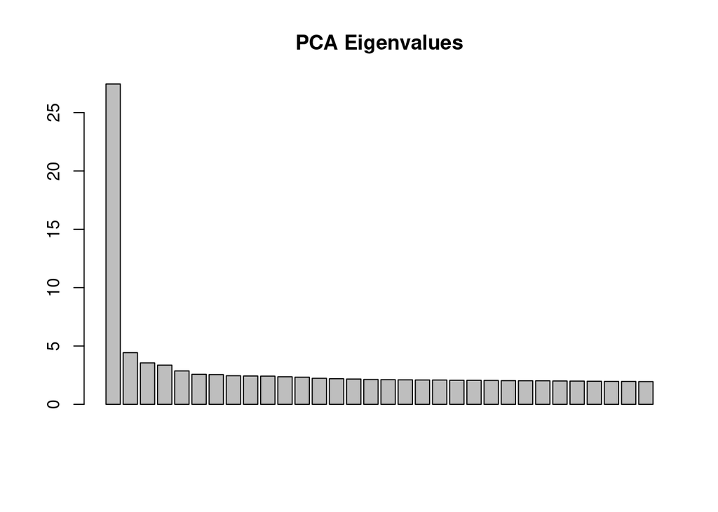

```r
#                               snp.id=snpset.id) # filtering for pruned SNPs
eig = pca.out$eigenval[!is.na(pca.out$eigenval)]
barplot(100*eig/sum(eig), main="PCA Eigenvalues")
```

- If you used sample replicates, first see if replicates cluster very close together. If not, then there may be batch effects or bioinformatic artifacts leading to genotyping error that must be addressed. Then remove replicates for a subsequent PCA evaluation.

```r
#look at PC values for reps
#remove reps
```

First color/shape the individuals by the factor you expect to matter (eg, sampling site or region, family, ecotype).

```
## Too few points to calculate an ellipse
## Too few points to calculate an ellipse
## Too few points to calculate an ellipse
```

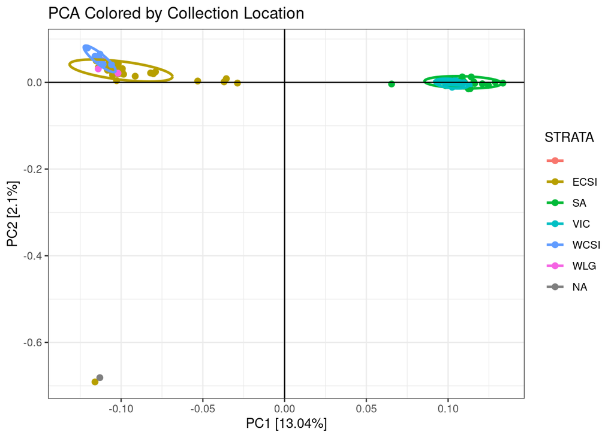

```r
#PLOT PCA
#PC1 v PC2 colored by collection location
print(
  as.data.frame(pca.out$eigenvect) %>%
      #tibble::add_column(., ID =  sample.ids) %>%
      tibble::add_column(., STRATA =  sample.strata.order$STRATA) %>%
      ggplot(., aes(x=V1, y=V2, color = STRATA))  + #label = ID
      geom_point(size=2) +
      #geom_text() +
      stat_ellipse(level = 0.95, size = 1) +
      #scale_color_manual(values = gds_colors) +
      geom_hline(yintercept = 0) +
      geom_vline(xintercept = 0) +
      theme_bw() +
      xlab(paste0("PC1 [",paste0(round(eig[1], 2)), "%]")) +
      ylab(paste0("PC2 [",paste0(round(eig[2], 2)), "%]")) +
      ggtitle("PCA Colored by Collection Location")
)
```

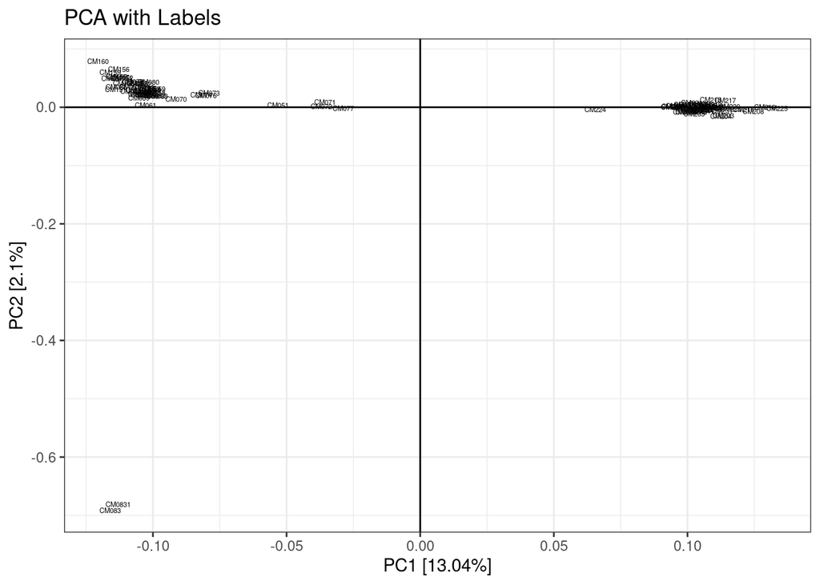

```r
#PLOT PCA
#PC1 v PC2 colored by collection location
print(
  as.data.frame(pca.out$eigenvect) %>%
      tibble::add_column(., ID =  sample.ids) %>%
      ggplot(., aes(x=V1, y=V2, label = ID)) +
      geom_text(size =1.5) +
      geom_hline(yintercept = 0) +
      geom_vline(xintercept = 0) +
      theme_bw() +
      xlab(paste0("PC1 [",paste0(round(eig[1], 2)), "%]")) +
      ylab(paste0("PC2 [",paste0(round(eig[2], 2)), "%]")) +
      ggtitle("PCA with Labels")
)
```

```r
# which samples have PC1 < -0.1 and PC2 < -0.6?
as.data.frame(pca.out$eigenvect) %>%
      tibble::add_column(., ID =  sample.ids) %>%
  filter(V1 < -0.1 & V2 < -0.6) %>%
  select(ID,V1,V2)
```

```
##       ID         V1         V2
## 1  CM083 -0.1159629 -0.6910028
## 2 CM0831 -0.1130069 -0.6811986
```

Next, color the individuals by potential sources of batch effects (sequencing lane, library prep batch, age of tissue sample, person doing the DNA extraction…).

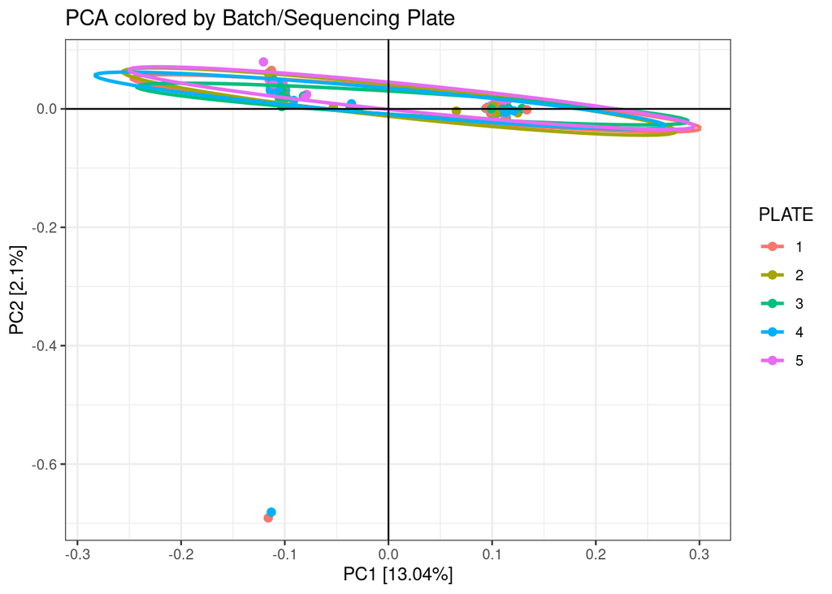

```r
# again, but colored by batch
print(
  as.data.frame(pca.out$eigenvect) %>%
      tibble::add_column(., PLATE =  as.factor(sample.strata.order$PLATE)) %>%
      ggplot(., aes(x=V1, y=V2, color = PLATE))  + #label = ID
      geom_point(size=2) +
      stat_ellipse(level = 0.95, size = 1) +
      geom_hline(yintercept = 0) +
      geom_vline(xintercept = 0) +
      theme_bw() +
      xlab(paste0("PC1 [",paste0(round(eig[1], 2)), "%]")) +
      ylab(paste0("PC2 [",paste0(round(eig[2], 2)), "%]")) +
      ggtitle("PCA colored by Batch/Sequencing Plate")
)
```

- Do any observed clusters match a source of batch effect? how to remove batch effects

#### Batch effects

As discussed in Setting up for success, batch effects can arise by minor (or not so minor) differences during the library prep and sequencing stage. Randomizing samples across libraries and sequencing lanes can help mitigate the influence of batch effects on your downstream analyses, but sometimes this isn’t possible, esp. when using pre-existing data. Even if you randomize your samples, it is a good idea to check for batch effects with a PCA and then try to mitigate them.

You can identify which loci are driving the batch effect by 1) identifying the top PC loadings (SNPs) and/or 2) do an Fst outlier analysis with the batches specified as populations (eg, Bayescan). Both of these methods are most appropriate if you’ve randomized your samples between batches. If you have not randomized samples but are certain there is a batch effect driving variation in your dataset, you can still remove loci this way but you may also be removing biologically informative loci.

Nicolas Lou and Nina Therkildsen have a [great preprint](https://www.authorea.com/users/380682/articles/532568-batch-effects-in-population-genomic-studies-with-low-coverage-whole-genome-sequencing-data-causes-detection-and-mitigation) and [Github repo](https://github.com/therkildsen-lab/batch-effect) discussing causes, detection, and mitigation of batch effects in low coverage WGS, where batch effects can have particularly large effects. While some of their recommendations are specific to reference-based analyses, others are relevant to RAD methods too (eg, batch effects due to different sequencing platforms, DNA degradation levels, and sequencing depth).

#### Cryptic species/contamination/clones

You can also check heterozygosity, and missingness!

You can then estimate genetic divergence between these clusters using pairwise Fst and/or phylogenetic inference to determine how diverged the groups are. If they are very diverged, it may be better to assemble each cryptic species separately, especially for denovo assemblies with dDocent and Stacks, especially since often times restriction cut-sites are not always conserved; see Wagner et al., 2013, Rubin et al., 2012 These two pipelines used a set of given samples to create a “reference” or “catalog” to which all other samples are mapped. If highly diverged samples are included in creating this reference, it can lead to oversplitting.

#### “Bad” samples

Sometimes a sample doesn’t sequence well (few sequencing reads, higher error rate). This can be due to DNA quality, an issue during library prep, or not enough sequencing depth (average # of reads per sample). Generally, it will lead to a sample with fewer sequencing reads, higher missing data in a SNP dataset, and fewer shared loci with other samples. Identifying and then removing these samples *prior* to the final RADseq assembly analysis can help minimize mis-assembled loci, genotyping errors, and excessive filtering of acceptable loci.

The process of identifying low quality individuals is usually iterative, as the way you initially filter your SNPs will influence the amount of missing data and locus sharing among samples. This is why we recommend minimally filtering your SNPs for sample coverage (the # of individuals a locus is called in) when initially exploring your data. Some ways to identify bad samples:

- For every SNP dataset you generate, it is a good idea is always evaluate the missingness per sample (and report this distribution in your manuscript!). Identify samples with way more missingness than the rest, and observe how they look in a PCA and locus sharing plot. If they stick out, then try removing them from the assembly and seeing if it changes downstream analyses. If so, you may want to specify a missingness cutoff for including samples in the final analysis. **vcftools example, on the command line**

```bash
vcftools --vcf data/stickleback_ferchaud_2015.vcf --missing-indv --out analysis/stickleback
# sort the file by most missing data and print the top 10
cat analysis/stickleback.imiss | (read h; echo "$h"; sort -k5 -r) | head -n 10
```

```
##
## VCFtools - 0.1.15
## (C) Adam Auton and Anthony Marcketta 2009
##
## Parameters as interpreted:
##  --vcf data/stickleback_ferchaud_2015.vcf
##  --missing-indv
##  --out analysis/stickleback
##
## After filtering, kept 177 out of 177 Individuals
## Outputting Individual Missingness
## After filtering, kept 31802 out of a possible 31802 Sites
## Run Time = 2.00 seconds
## INDV N_DATA  N_GENOTYPES_FILTERED    N_MISS  F_MISS
## Kibeak6_q_75.align   31802   0   31785   0.999465
## Mosso23_q_75.align   31802   0   7506    0.236023
## Hald_So23_q_75.align 31802   0   7415    0.233161
## Mosso24_q_75.align   31802   0   3985    0.125307
## Hadsten1_q_75.align  31802   0   3887    0.122225
## Mosso20_q_75.align   31802   0   3544    0.11144
## Hald_So1_q_75.align  31802   0   3459    0.108767
## Hald_So25_q_75.align 31802   0   3262    0.102572
## Mosso22_q_75.align   31802   0   3060    0.0962204
```

##### Plot missingness

###### With R

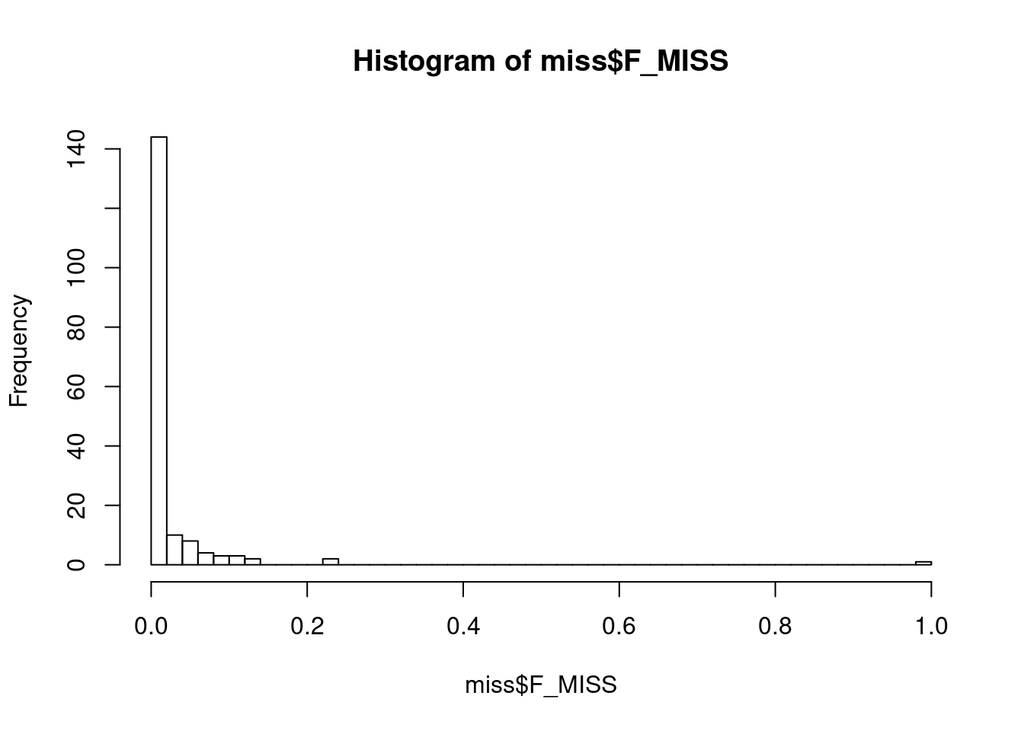

```r
miss <- read.table("analysis/stickleback.imiss",header = T,sep="\t")
hist(miss$F_MISS,breaks=50)
```

###### With bash (requires gnuplot installed)

```bash
#code from Jon Puritz
mawk '!/IN/' analysis/stickleback.imiss | cut -f5 > totalmissing
gnuplot << \EOF
set terminal dumb size 120, 30
set autoscale
unset label
set title "Histogram of % missing data per individual"
set ylabel "Number of Occurrences"
set xlabel "% of missing data"
#set yr [0:100000]
binwidth=0.01
bin(x,width)=width*floor(x/width) + binwidth/2.0
plot 'totalmissing' using (bin($1,binwidth)):(1.0) smooth freq with boxes
pause -1
EOF
```

```
##
##                                          Histogram of % missing data per individual
##
##      140 +----------------------------------------------------------------------------------------------------------+
##          |*         +         +          +          +          +         +          +          +         +          |
##          |*                                                   'totalmissing' using (bin($1,binwidth)):(1.0) ******* |
##      120 |*+                                                                                                      +-|
##          |*                                                                                                         |
##          |*                                                                                                         |
##          |*                                                                                                         |
##      100 |*+                                                                                                      +-|
##          |*                                                                                                         |
##          |*                                                                                                         |
##       80 |*+                                                                                                      +-|
##          |*                                                                                                         |
##          |*                                                                                                         |
##       60 |*+                                                                                                      +-|
##          |*                                                                                                         |
##          |*                                                                                                         |
##       40 |*+                                                                                                      +-|
##          |*                                                                                                         |
##          |*                                                                                                         |
##          |*                                                                                                         |
##       20 |*+                                                                                                      +-|
##          |**                                                                                                        |
##          |******    +         +          +          +          +         +          +          +         +          |
##        0 +----------------------------------------------------------------------------------------------------------+
##          0         0.1       0.2        0.3        0.4        0.5       0.6        0.7        0.8       0.9         1
##                                                       % of missing data
##
```

- Construct a locus sharing heatmap between pairs of samples, which shows the proportion of loci that are genotyped in both samples. Generally, samples that are more closely related will share more loci with each other due to cutsite dropout. Deviations from that pattern can pinpoint bad samples as well as batch effects.
  - [ipyrad API tutorial](https://ipyrad.readthedocs.io/en/latest/API-analysis/cookbook-sharing.html) for making a locus sharing heatmap, requires ipyrad output or ipyrad’s vcf2hdf5 conversion
  - [code to generate locus sharing/missingness heatmap from a VCF](https://github.com/atcg/clustOpt)

### Test a range of key parameters

#### Clustering threshold (de novo assembly)

There are a few strategies to identify a good clustering threshold for your data, all of which require assembling your data with a range of clustering thresholds.  
1) Metrics developed by McCartney-Melstad 2017, based on popgen theory and landscape genetic expectations  
2) Utilize sample replicates (either exact replicates or individuals from the same locality) to quantify genotyping error and minimize error while maximizing the number of informative loci Mastretta-Yanes 2015 3) Evaluating the number of haplotypes across loci, with many 3+ haplotypes indicating undersplitting Harvey 2015, Ilut 2014  
4) Make assemblies at a range of thresholds and parameters, plot the # of SNPs or contigs per assembly, and make a judgement call example in dDocent tutorial. If most parameters give you about the same # of SNPs or contigs, you can feel confident that this parameter doesn’t matter much for your data and just choose a reasonable value.

Puritz has experimental script to optimize ref assemblies, look at it

#### Mapping parameters (reference-based and some de novo assemblers)

When a sequencing read maps to the wrong assembled contig or place in a reference genome (ie, a non-homologous locus), this can result in erroneous SNPs. In many cases, these SNPs can be filtered out later (link to filtering). However, data should be checked to make sure there aren’t systematic, wide-scale mapping issues that need to be addressed.

For referenced-based assembly, both dDocent and ipyrad make use of bwa(link) to map reads, while Stacks allows the user to choose their aligner. dDocent also utilizes bwa for de novo assemblies. *

- how many reads aligned for each sample? If many reads didn’t aligned, this could be an issue with the reference, read trimming/filtering, or the mapping parameters.
- What is the distribution of mapping scores?
- ratio of mean (across inds) mapping quality scores for reference and alternate allele (O’Leary cite). 0.25-1.75 cut off implemented in dDocent.
  - this info might not be coded in all VCFs

talk to WGS group to see what they say about visualizing mapping quality

Mapping defaults: dDocent: bwa mem -L 20,5 -t 8 -a -M -T 10 -A1 -B 3 -O 5 -R L: clipping penalty for 5’ and 3’ A: matching score O gap open penalty T: mapping quality filter ipyrad: (defaults) -L 5,5 -B 4 -A1 -O 6 -T 30

#### Read depth threshold

Mistakes that occur during sequencing can lead to a base-calling error in a read, which can then lead to an erroneous SNP. This type of error most commonly manifests as rare alleles (eg, only observed in one individual) or singletons (only one copy of the minor allele across all individuals). A conservative approach to deal with these errors is to filter out all loci with rare alleles (link filtering), but for some demographic analyses this filtering is inappropriate as they require the site frequency spectrum.  
The best ways to minimize the impact of sequencing error during bioinformatic processing is to 1) properly trim and filter your data, and 2) require higher read depth thresholds for assembly and genotyping.

ask popgen group, what are ways to check for sequencing error  
Fountain et al 2016 found error rates > 0.06 with minimum 20 read depth and Stacks v1. Can this be due to not optimizing other Stacks parameters? Hard to interpret/ know how relevant it is now, even to Stacks2

#### Filtering reads

FASTQ files that typically come from the sequencing center include a Phred scale quality score for each base, which indicates the probability of that base call being correct. This information can be used prior to assembly to trim low-quality sections from either end of reads or remove reads altogether. Some SNP callers, including FreeBayes which is part of dDocent, also use Phred scores when calling SNPs (ipyrad and Stacks do not). All three of the most popular RAD pipelines include steps to filter reads due to low quality bases low quality bases or adapter sequences, but vary slightly on what kinds of read trimming are allowed. Always make sure to filter out adapter sequences (this is not default with stacks), otherwise default parameters are usually adequate. If your initial fastqc indicates that you have many low quality bases in your reads, you may lose too much of your data during filtering. In this case, you may want to make your read filtering a little more permissible (keeping in mind that this may increase SNP error rate).  
**Always make sure to check with your sequencing center to see if they have done anything to the raw reads before you received them!**

**dDocent:**

- does not allow you to use reads that have already been trimmed and filtered for de novo assembly, only referenced-based.
- Uses Trimmomatic to trim Illumina TruSeq adaters and low quality bases. Make sure to change the defaults if you used a different adapter/sequencing system.

**Stacks:**

- requires your reads to be all the same length, so if they were previously trimmed of low quality bases or adapter sequence this must be specified and they will be truncated to the same length.

### Filter your data many ways (and embrace the missingness!)

- Don’t over filter for missingness
- papers showing how too much filtering can skew results
- Empirical: Diaz-Arce 2019, Tripp 2017, Silliman 2021, Eaton 2017, Martin-Hernanz (2019)
- Simulations: Huang & Knowles 2016, Leaché et al., 2015, Gautier et al., 2012, Rivera-Colón et al., 2021
- some ways to account for missing data in downstream analyses
- impute (PCA), subsample (PCA, structure, pretty much anything with SNPs), try a few different missing filters and see what impact it has on results
- use pcANGSD

## Assembly and Genotyping Pipelines

There are a number of freely available pipelines for processing RADseq data, with the most popular being dDocent, Stacks, and ipyrad. These pipelines vary slightly in their underlying methodologies, customization options, and additional included analyses.

[output not shown]

Some groups have also developed pipelines for specific flavors of lab (e.g., Matz lab and 2bRAD) or proprietary software (eg, DARTseq), which we touch on below. **In most cases, it is recommended that you use a pipeline developed and tested for RAD data, especially if you are making a de novo assembly.** LaCava et al, 2019 have an excellent study where they review various de novo assemblers that are used in these pipelines. Assemblers that were not explicitly developed for short reads (eg, Velvet, ABySS) performed very poorly, while CD-HIT (the assembler in dDocent) performed the best. Stacks/Stacks2 and vsearch (the assembler in ipyrad) both performed worse when analyzing simulated data with indels. It should be noted that all of these RAD pipelines have optimized the specific parameters of these de novo assemblers to work with RAD data of various flavors, which may not be fully reflected in the LaCava study. Based on the MarineOmics RAD panel, the general consensus is that all the popular pipelines can produce adequately accurate datasets (with appropriate parameter optimization and data filtering).

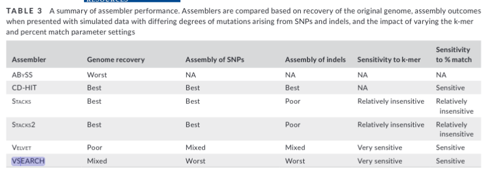

### iPyrad walkthrough

Link to annotated ipyrad notebook

## Special Cases

### 2bRAD

## RADseq/GBS vs. WGS?

Take more notes from RAD and WGS panels to fill in section. Add some RAD review papers

### Reference-based vs. de novo RADseq

## Good tutorials

- [Marine Genomics open course](https://baylab.github.io/MarineGenomics/)
- [UNIX tutorial](http://evomics.org/learning/unix-tutorial/)
- [what is a VCF file and how can I filter it?](http://evomics.org/learning/population-and-speciation-genomics/2020-population-and-speciation-genomics/first-steps-in-genomic-data-analysis/)